# Risk Factor Analysis

## Outcome Variable

**Outcome Variable:** y_rate_wtkg

## Predictor Variables

**Intervention Variable:** predfeed36

**Adjustment Set:**

- arm
- sex
- month
- brthmon
- W_mage
- meducyrs
- feducyrs
- hhwealth_quart
- hfoodsec
- W_mhtcm
- W_mwtkg
- W_mbmi
- vagbrth
- W_birthwt
- W_birthlen
- single
- W_nrooms
- impfloor
- impsan
- safeh20
- delta_W_mage
- delta_meducyrs
- delta_feducyrs
- delta_hhwealth_quart
- delta_hfoodsec
- delta_W_mhtcm
- delta_W_mwtkg
- delta_W_mbmi
- delta_vagbrth
- delta_W_birthwt
- delta_W_birthlen
- delta_single
- delta_W_nrooms
- delta_impfloor
- delta_impsan
- delta_safeh20

## Stratifying Variables

The analysis was stratified on these variable(s):

- agecat
- studyid
- country

## Data Summary

| agecat | studyid | country | predfeed36 | n_cell | n | outcome_variable |
| --- | --- | --- | --- | --- | --- | --- |
| 0-3 months | ki0047075b-MAL-ED | BANGLADESH | 1 | 83 | 245 | y_rate_wtkg |
| 0-3 months | ki0047075b-MAL-ED | BANGLADESH | 0 | 162 | 245 | y_rate_wtkg |
| 0-3 months | ki0047075b-MAL-ED | BRAZIL | 1 | 27 | 217 | y_rate_wtkg |
| 0-3 months | ki0047075b-MAL-ED | BRAZIL | 0 | 190 | 217 | y_rate_wtkg |
| 0-3 months | ki0047075b-MAL-ED | INDIA | 1 | 18 | 235 | y_rate_wtkg |
| 0-3 months | ki0047075b-MAL-ED | INDIA | 0 | 217 | 235 | y_rate_wtkg |
| 0-3 months | ki0047075b-MAL-ED | NEPAL | 1 | 9 | 230 | y_rate_wtkg |
| 0-3 months | ki0047075b-MAL-ED | NEPAL | 0 | 221 | 230 | y_rate_wtkg |
| 0-3 months | ki0047075b-MAL-ED | PERU | 1 | 77 | 280 | y_rate_wtkg |
| 0-3 months | ki0047075b-MAL-ED | PERU | 0 | 203 | 280 | y_rate_wtkg |
| 0-3 months | ki0047075b-MAL-ED | SOUTH AFRICA | 1 | 5 | 268 | y_rate_wtkg |
| 0-3 months | ki0047075b-MAL-ED | SOUTH AFRICA | 0 | 263 | 268 | y_rate_wtkg |
| 0-3 months | ki0047075b-MAL-ED | TANZANIA, UNITED REPUBLIC OF | 1 | 4 | 232 | y_rate_wtkg |
| 0-3 months | ki0047075b-MAL-ED | TANZANIA, UNITED REPUBLIC OF | 0 | 228 | 232 | y_rate_wtkg |
| 0-3 months | ki1000109-EE | PAKISTAN | 1 | 3 | 7 | y_rate_wtkg |
| 0-3 months | ki1000109-EE | PAKISTAN | 0 | 4 | 7 | y_rate_wtkg |
| 0-3 months | ki1113344-GMS-Nepal | NEPAL | 1 | 373 | 466 | y_rate_wtkg |
| 0-3 months | ki1113344-GMS-Nepal | NEPAL | 0 | 93 | 466 | y_rate_wtkg |
| 0-3 months | kiGH5241-JiVitA-3 | BANGLADESH | 1 | 7731 | 9920 | y_rate_wtkg |
| 0-3 months | kiGH5241-JiVitA-3 | BANGLADESH | 0 | 2189 | 9920 | y_rate_wtkg |
| 0-3 months | kiGH5241-JiVitA-4 | BANGLADESH | 1 | 1916 | 2293 | y_rate_wtkg |
| 0-3 months | kiGH5241-JiVitA-4 | BANGLADESH | 0 | 377 | 2293 | y_rate_wtkg |
| 3-6 months | ki0047075b-MAL-ED | BANGLADESH | 1 | 78 | 232 | y_rate_wtkg |
| 3-6 months | ki0047075b-MAL-ED | BANGLADESH | 0 | 154 | 232 | y_rate_wtkg |
| 3-6 months | ki0047075b-MAL-ED | BRAZIL | 1 | 25 | 208 | y_rate_wtkg |
| 3-6 months | ki0047075b-MAL-ED | BRAZIL | 0 | 183 | 208 | y_rate_wtkg |
| 3-6 months | ki0047075b-MAL-ED | INDIA | 1 | 17 | 228 | y_rate_wtkg |
| 3-6 months | ki0047075b-MAL-ED | INDIA | 0 | 211 | 228 | y_rate_wtkg |
| 3-6 months | ki0047075b-MAL-ED | NEPAL | 1 | 8 | 232 | y_rate_wtkg |
| 3-6 months | ki0047075b-MAL-ED | NEPAL | 0 | 224 | 232 | y_rate_wtkg |

[output cut: 150 more lines]

The following strata were considered:

- agecat: 0-3 months, studyid: ki0047075b-MAL-ED, country: BANGLADESH
- agecat: 0-3 months, studyid: ki0047075b-MAL-ED, country: BRAZIL
- agecat: 0-3 months, studyid: ki0047075b-MAL-ED, country: INDIA
- agecat: 0-3 months, studyid: ki0047075b-MAL-ED, country: NEPAL
- agecat: 0-3 months, studyid: ki0047075b-MAL-ED, country: PERU
- agecat: 0-3 months, studyid: ki0047075b-MAL-ED, country: SOUTH AFRICA
- agecat: 0-3 months, studyid: ki0047075b-MAL-ED, country: TANZANIA, UNITED REPUBLIC OF
- agecat: 0-3 months, studyid: ki1000109-EE, country: PAKISTAN
- agecat: 0-3 months, studyid: ki1113344-GMS-Nepal, country: NEPAL
- agecat: 0-3 months, studyid: kiGH5241-JiVitA-3, country: BANGLADESH
- agecat: 0-3 months, studyid: kiGH5241-JiVitA-4, country: BANGLADESH
- agecat: 12-15 months, studyid: ki0047075b-MAL-ED, country: BANGLADESH
- agecat: 12-15 months, studyid: ki0047075b-MAL-ED, country: BRAZIL
- agecat: 12-15 months, studyid: ki0047075b-MAL-ED, country: INDIA
- agecat: 12-15 months, studyid: ki0047075b-MAL-ED, country: NEPAL
- agecat: 12-15 months, studyid: ki0047075b-MAL-ED, country: PERU
- agecat: 12-15 months, studyid: ki0047075b-MAL-ED, country: SOUTH AFRICA
- agecat: 12-15 months, studyid: ki0047075b-MAL-ED, country: TANZANIA, UNITED REPUBLIC OF
- agecat: 12-15 months, studyid: ki1000109-EE, country: PAKISTAN
- agecat: 12-15 months, studyid: ki1000304b-SAS-FoodSuppl, country: INDIA
- agecat: 12-15 months, studyid: ki1113344-GMS-Nepal, country: NEPAL
- agecat: 12-15 months, studyid: ki1148112-LCNI-5, country: MALAWI
- agecat: 12-15 months, studyid: kiGH5241-JiVitA-4, country: BANGLADESH
- agecat: 15-18 months, studyid: ki0047075b-MAL-ED, country: BANGLADESH
- agecat: 15-18 months, studyid: ki0047075b-MAL-ED, country: BRAZIL
- agecat: 15-18 months, studyid: ki0047075b-MAL-ED, country: INDIA
- agecat: 15-18 months, studyid: ki0047075b-MAL-ED, country: NEPAL
- agecat: 15-18 months, studyid: ki0047075b-MAL-ED, country: PERU
- agecat: 15-18 months, studyid: ki0047075b-MAL-ED, country: SOUTH AFRICA
- agecat: 15-18 months, studyid: ki0047075b-MAL-ED, country: TANZANIA, UNITED REPUBLIC OF
- agecat: 15-18 months, studyid: ki1000109-EE, country: PAKISTAN
- agecat: 15-18 months, studyid: ki1000304b-SAS-FoodSuppl, country: INDIA
- agecat: 15-18 months, studyid: ki1113344-GMS-Nepal, country: NEPAL
- agecat: 15-18 months, studyid: ki1148112-LCNI-5, country: MALAWI
- agecat: 15-18 months, studyid: kiGH5241-JiVitA-4, country: BANGLADESH
- agecat: 18-21 months, studyid: ki0047075b-MAL-ED, country: BANGLADESH
- agecat: 18-21 months, studyid: ki0047075b-MAL-ED, country: BRAZIL
- agecat: 18-21 months, studyid: ki0047075b-MAL-ED, country: INDIA
- agecat: 18-21 months, studyid: ki0047075b-MAL-ED, country: NEPAL
- agecat: 18-21 months, studyid: ki0047075b-MAL-ED, country: PERU
- agecat: 18-21 months, studyid: ki0047075b-MAL-ED, country: SOUTH AFRICA
- agecat: 18-21 months, studyid: ki0047075b-MAL-ED, country: TANZANIA, UNITED REPUBLIC OF
- agecat: 18-21 months, studyid: ki1000109-EE, country: PAKISTAN
- agecat: 18-21 months, studyid: ki1113344-GMS-Nepal, country: NEPAL
- agecat: 18-21 months, studyid: ki1148112-LCNI-5, country: MALAWI
- agecat: 21-24 months, studyid: ki0047075b-MAL-ED, country: BANGLADESH
- agecat: 21-24 months, studyid: ki0047075b-MAL-ED, country: BRAZIL
- agecat: 21-24 months, studyid: ki0047075b-MAL-ED, country: INDIA
- agecat: 21-24 months, studyid: ki0047075b-MAL-ED, country: NEPAL
- agecat: 21-24 months, studyid: ki0047075b-MAL-ED, country: PERU
- agecat: 21-24 months, studyid: ki0047075b-MAL-ED, country: SOUTH AFRICA
- agecat: 21-24 months, studyid: ki0047075b-MAL-ED, country: TANZANIA, UNITED REPUBLIC OF
- agecat: 21-24 months, studyid: ki1000109-EE, country: PAKISTAN
- agecat: 21-24 months, studyid: ki1113344-GMS-Nepal, country: NEPAL
- agecat: 21-24 months, studyid: ki1148112-LCNI-5, country: MALAWI
- agecat: 3-6 months, studyid: ki0047075b-MAL-ED, country: BANGLADESH
- agecat: 3-6 months, studyid: ki0047075b-MAL-ED, country: BRAZIL
- agecat: 3-6 months, studyid: ki0047075b-MAL-ED, country: INDIA
- agecat: 3-6 months, studyid: ki0047075b-MAL-ED, country: NEPAL
- agecat: 3-6 months, studyid: ki0047075b-MAL-ED, country: PERU
- agecat: 3-6 months, studyid: ki0047075b-MAL-ED, country: SOUTH AFRICA
- agecat: 3-6 months, studyid: ki0047075b-MAL-ED, country: TANZANIA, UNITED REPUBLIC OF
- agecat: 3-6 months, studyid: ki1000109-EE, country: PAKISTAN
- agecat: 3-6 months, studyid: ki1113344-GMS-Nepal, country: NEPAL
- agecat: 3-6 months, studyid: kiGH5241-JiVitA-3, country: BANGLADESH
- agecat: 3-6 months, studyid: kiGH5241-JiVitA-4, country: BANGLADESH
- agecat: 6-9 months, studyid: ki0047075b-MAL-ED, country: BANGLADESH
- agecat: 6-9 months, studyid: ki0047075b-MAL-ED, country: BRAZIL
- agecat: 6-9 months, studyid: ki0047075b-MAL-ED, country: INDIA
- agecat: 6-9 months, studyid: ki0047075b-MAL-ED, country: NEPAL
- agecat: 6-9 months, studyid: ki0047075b-MAL-ED, country: PERU
- agecat: 6-9 months, studyid: ki0047075b-MAL-ED, country: SOUTH AFRICA
- agecat: 6-9 months, studyid: ki0047075b-MAL-ED, country: TANZANIA, UNITED REPUBLIC OF
- agecat: 6-9 months, studyid: ki1000109-EE, country: PAKISTAN
- agecat: 6-9 months, studyid: ki1000304b-SAS-FoodSuppl, country: INDIA
- agecat: 6-9 months, studyid: ki1113344-GMS-Nepal, country: NEPAL
- agecat: 6-9 months, studyid: ki1148112-LCNI-5, country: MALAWI
- agecat: 6-9 months, studyid: kiGH5241-JiVitA-4, country: BANGLADESH
- agecat: 9-12 months, studyid: ki0047075b-MAL-ED, country: BANGLADESH
- agecat: 9-12 months, studyid: ki0047075b-MAL-ED, country: BRAZIL
- agecat: 9-12 months, studyid: ki0047075b-MAL-ED, country: INDIA
- agecat: 9-12 months, studyid: ki0047075b-MAL-ED, country: NEPAL
- agecat: 9-12 months, studyid: ki0047075b-MAL-ED, country: PERU
- agecat: 9-12 months, studyid: ki0047075b-MAL-ED, country: SOUTH AFRICA
- agecat: 9-12 months, studyid: ki0047075b-MAL-ED, country: TANZANIA, UNITED REPUBLIC OF
- agecat: 9-12 months, studyid: ki1000109-EE, country: PAKISTAN
- agecat: 9-12 months, studyid: ki1000304b-SAS-FoodSuppl, country: INDIA
- agecat: 9-12 months, studyid: ki1113344-GMS-Nepal, country: NEPAL
- agecat: 9-12 months, studyid: ki1148112-LCNI-5, country: MALAWI
- agecat: 9-12 months, studyid: kiGH5241-JiVitA-4, country: BANGLADESH

### Dropped Strata

Some strata were dropped due to rare outcomes:

- agecat: 0-3 months, studyid: ki0047075b-MAL-ED, country: TANZANIA, UNITED REPUBLIC OF
- agecat: 0-3 months, studyid: ki1000109-EE, country: PAKISTAN
- agecat: 3-6 months, studyid: ki0047075b-MAL-ED, country: SOUTH AFRICA
- agecat: 3-6 months, studyid: ki1000109-EE, country: PAKISTAN
- agecat: 6-9 months, studyid: ki0047075b-MAL-ED, country: SOUTH AFRICA
- agecat: 6-9 months, studyid: ki1000109-EE, country: PAKISTAN
- agecat: 6-9 months, studyid: ki1000304b-SAS-FoodSuppl, country: INDIA
- agecat: 9-12 months, studyid: ki0047075b-MAL-ED, country: SOUTH AFRICA
- agecat: 9-12 months, studyid: ki0047075b-MAL-ED, country: TANZANIA, UNITED REPUBLIC OF
- agecat: 9-12 months, studyid: ki1000109-EE, country: PAKISTAN
- agecat: 9-12 months, studyid: ki1000304b-SAS-FoodSuppl, country: INDIA
- agecat: 12-15 months, studyid: ki0047075b-MAL-ED, country: SOUTH AFRICA
- agecat: 12-15 months, studyid: ki0047075b-MAL-ED, country: TANZANIA, UNITED REPUBLIC OF
- agecat: 12-15 months, studyid: ki1000109-EE, country: PAKISTAN
- agecat: 12-15 months, studyid: ki1000304b-SAS-FoodSuppl, country: INDIA
- agecat: 12-15 months, studyid: ki1148112-LCNI-5, country: MALAWI
- agecat: 15-18 months, studyid: ki0047075b-MAL-ED, country: SOUTH AFRICA
- agecat: 15-18 months, studyid: ki0047075b-MAL-ED, country: TANZANIA, UNITED REPUBLIC OF
- agecat: 15-18 months, studyid: ki1000109-EE, country: PAKISTAN
- agecat: 15-18 months, studyid: ki1000304b-SAS-FoodSuppl, country: INDIA
- agecat: 15-18 months, studyid: ki1148112-LCNI-5, country: MALAWI
- agecat: 18-21 months, studyid: ki0047075b-MAL-ED, country: SOUTH AFRICA
- agecat: 18-21 months, studyid: ki0047075b-MAL-ED, country: TANZANIA, UNITED REPUBLIC OF
- agecat: 18-21 months, studyid: ki1000109-EE, country: PAKISTAN
- agecat: 21-24 months, studyid: ki0047075b-MAL-ED, country: SOUTH AFRICA
- agecat: 21-24 months, studyid: ki0047075b-MAL-ED, country: TANZANIA, UNITED REPUBLIC OF
- agecat: 21-24 months, studyid: ki1000109-EE, country: PAKISTAN

## Methods Detail

We’re interested in the causal parameters $E[Y_a]$ for all values of $a \in \mathcal{A}$. These parameters represent the mean outcome if, possibly contrary to fact, we intervened to set all units to have $A=a$. Under the randomization and positivity assumptions, these are identified by the statistical parameters $\psi_a=E_W[E_{Y|A,W}(Y|A=a,W)]$. In addition, we’re interested in the mean of $Y$, $E[Y]$ under no intervention (the observed mean). We will estimate these parameters by using SuperLearner to fit the relevant likelihood factors – $E_{Y|A,W}(Y|A=a,W)$ and $p(A=a|W)$, and then updating our likelihood fit using a joint TMLE.

For unadjusted analyses ($W=\{\}$), initial likelihoods were estimated using Lrnr_glm to estimate the simple $E(Y|A)$ and Lrnr_mean to estimate $p(A)$. For adjusted analyses, a small library containing Lrnr_glmnet, Lrnr_xgboost, and Lrnr_mean was used.

Having estimated these parameters, we will then use the delta method to estimate relative risks and attributable risks relative to a prespecified baseline level of $A$.

# Results Detail

## Results Plots

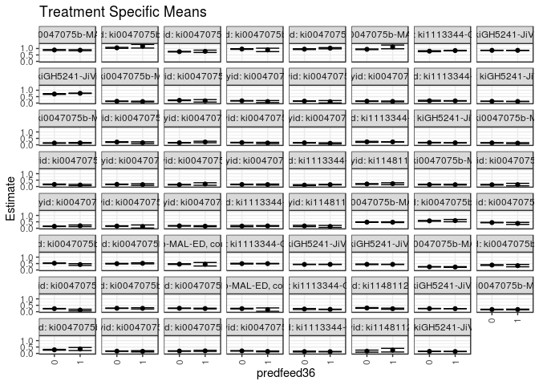

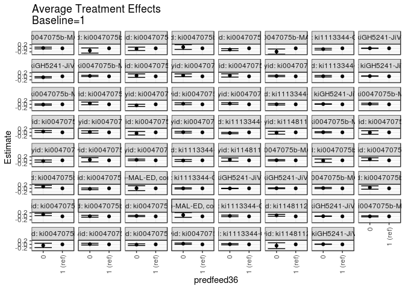

[figure not shown]

## Results Table

### Parameter: TSM

| agecat | studyid | country | intervention_level | baseline_level | estimate | ci_lower | ci_upper |
| --- | --- | --- | --- | --- | --- | --- | --- |
| 0-3 months | ki0047075b-MAL-ED | BANGLADESH | 1 | NA | 0.8687140 | 0.8316257 | 0.9058023 |
| 0-3 months | ki0047075b-MAL-ED | BANGLADESH | 0 | NA | 0.8848243 | 0.8551321 | 0.9145166 |
| 0-3 months | ki0047075b-MAL-ED | BRAZIL | 1 | NA | 1.1776862 | 1.0357411 | 1.3196314 |
| 0-3 months | ki0047075b-MAL-ED | BRAZIL | 0 | NA | 1.0526783 | 1.0173916 | 1.0879649 |
| 0-3 months | ki0047075b-MAL-ED | INDIA | 1 | NA | 0.7825432 | 0.6924767 | 0.8726097 |
| 0-3 months | ki0047075b-MAL-ED | INDIA | 0 | NA | 0.7558567 | 0.7327043 | 0.7790090 |
| 0-3 months | ki0047075b-MAL-ED | NEPAL | 1 | NA | 0.8917231 | 0.7591937 | 1.0242525 |
| 0-3 months | ki0047075b-MAL-ED | NEPAL | 0 | NA | 0.9592919 | 0.9317769 | 0.9868068 |
| 0-3 months | ki0047075b-MAL-ED | PERU | 1 | NA | 1.0224690 | 0.9752999 | 1.0696381 |
| 0-3 months | ki0047075b-MAL-ED | PERU | 0 | NA | 0.9516559 | 0.9221721 | 0.9811397 |
| 0-3 months | ki0047075b-MAL-ED | SOUTH AFRICA | 1 | NA | 1.1240287 | 0.9802729 | 1.2677845 |
| 0-3 months | ki0047075b-MAL-ED | SOUTH AFRICA | 0 | NA | 0.9375440 | 0.9105230 | 0.9645650 |
| 0-3 months | ki1113344-GMS-Nepal | NEPAL | 1 | NA | 0.8385423 | 0.8185796 | 0.8585051 |
| 0-3 months | ki1113344-GMS-Nepal | NEPAL | 0 | NA | 0.7922806 | 0.7531595 | 0.8314016 |
| 0-3 months | kiGH5241-JiVitA-3 | BANGLADESH | 1 | NA | 0.8559213 | 0.8514910 | 0.8603515 |
| 0-3 months | kiGH5241-JiVitA-3 | BANGLADESH | 0 | NA | 0.8574327 | 0.8482018 | 0.8666637 |
| 0-3 months | kiGH5241-JiVitA-4 | BANGLADESH | 1 | NA | 0.7619144 | 0.7473403 | 0.7764885 |
| 0-3 months | kiGH5241-JiVitA-4 | BANGLADESH | 0 | NA | 0.7061516 | 0.6748297 | 0.7374735 |
| 3-6 months | ki0047075b-MAL-ED | BANGLADESH | 1 | NA | 0.4716293 | 0.4432332 | 0.5000255 |
| 3-6 months | ki0047075b-MAL-ED | BANGLADESH | 0 | NA | 0.4768224 | 0.4555099 | 0.4981349 |
| 3-6 months | ki0047075b-MAL-ED | BRAZIL | 1 | NA | 0.5946779 | 0.5063348 | 0.6830209 |
| 3-6 months | ki0047075b-MAL-ED | BRAZIL | 0 | NA | 0.5764087 | 0.5429029 | 0.6099145 |
| 3-6 months | ki0047075b-MAL-ED | INDIA | 1 | NA | 0.3790752 | 0.3009362 | 0.4572143 |
| 3-6 months | ki0047075b-MAL-ED | INDIA | 0 | NA | 0.4442438 | 0.4261726 | 0.4623151 |
| 3-6 months | ki0047075b-MAL-ED | NEPAL | 1 | NA | 0.4237838 | 0.3564157 | 0.4911520 |
| 3-6 months | ki0047075b-MAL-ED | NEPAL | 0 | NA | 0.5256796 | 0.5049974 | 0.5463618 |
| 3-6 months | ki0047075b-MAL-ED | PERU | 1 | NA | 0.5197411 | 0.4796043 | 0.5598779 |
| 3-6 months | ki0047075b-MAL-ED | PERU | 0 | NA | 0.4913759 | 0.4699045 | 0.5128473 |
| 3-6 months | ki0047075b-MAL-ED | TANZANIA, UNITED REPUBLIC OF | 1 | NA | 0.4474229 | 0.3122280 | 0.5826178 |
| 3-6 months | ki0047075b-MAL-ED | TANZANIA, UNITED REPUBLIC OF | 0 | NA | 0.4580815 | 0.4333589 | 0.4828041 |

[output cut: 96 more lines]

### Parameter: E(Y)

| agecat | studyid | country | intervention_level | baseline_level | estimate | ci_lower | ci_upper |
| --- | --- | --- | --- | --- | --- | --- | --- |
| 0-3 months | ki0047075b-MAL-ED | BANGLADESH | NA | NA | 0.8793764 | 0.8562449 | 0.9025078 |
| 0-3 months | ki0047075b-MAL-ED | BRAZIL | NA | NA | 1.0655134 | 1.0311555 | 1.0998713 |
| 0-3 months | ki0047075b-MAL-ED | INDIA | NA | NA | 0.7588477 | 0.7364127 | 0.7812826 |
| 0-3 months | ki0047075b-MAL-ED | NEPAL | NA | NA | 0.9566479 | 0.9296524 | 0.9836434 |
| 0-3 months | ki0047075b-MAL-ED | PERU | NA | NA | 0.9709635 | 0.9457785 | 0.9961485 |
| 0-3 months | ki0047075b-MAL-ED | SOUTH AFRICA | NA | NA | 0.9410232 | 0.9142620 | 0.9677844 |
| 0-3 months | ki1113344-GMS-Nepal | NEPAL | NA | NA | 0.8290682 | 0.8112267 | 0.8469097 |
| 0-3 months | kiGH5241-JiVitA-3 | BANGLADESH | NA | NA | 0.8562140 | 0.8521272 | 0.8603009 |
| 0-3 months | kiGH5241-JiVitA-4 | BANGLADESH | NA | NA | 0.7527222 | 0.7394082 | 0.7660362 |
| 3-6 months | ki0047075b-MAL-ED | BANGLADESH | NA | NA | 0.4740560 | 0.4573508 | 0.4907612 |
| 3-6 months | ki0047075b-MAL-ED | BRAZIL | NA | NA | 0.5781976 | 0.5469697 | 0.6094254 |
| 3-6 months | ki0047075b-MAL-ED | INDIA | NA | NA | 0.4437256 | 0.4262017 | 0.4612496 |
| 3-6 months | ki0047075b-MAL-ED | NEPAL | NA | NA | 0.5221660 | 0.5019198 | 0.5424121 |
| 3-6 months | ki0047075b-MAL-ED | PERU | NA | NA | 0.4982335 | 0.4792789 | 0.5171881 |
| 3-6 months | ki0047075b-MAL-ED | TANZANIA, UNITED REPUBLIC OF | NA | NA | 0.4578547 | 0.4335136 | 0.4821959 |
| 3-6 months | ki1113344-GMS-Nepal | NEPAL | NA | NA | 0.4969685 | 0.4829796 | 0.5109574 |
| 3-6 months | kiGH5241-JiVitA-3 | BANGLADESH | NA | NA | 0.4376750 | 0.4329472 | 0.4424029 |
| 3-6 months | kiGH5241-JiVitA-4 | BANGLADESH | NA | NA | 0.4386833 | 0.4295081 | 0.4478585 |
| 6-9 months | ki0047075b-MAL-ED | BANGLADESH | NA | NA | 0.2428552 | 0.2283339 | 0.2573765 |
| 6-9 months | ki0047075b-MAL-ED | BRAZIL | NA | NA | 0.3831499 | 0.3570859 | 0.4092138 |
| 6-9 months | ki0047075b-MAL-ED | INDIA | NA | NA | 0.2306231 | 0.2156296 | 0.2456166 |
| 6-9 months | ki0047075b-MAL-ED | NEPAL | NA | NA | 0.2699886 | 0.2554702 | 0.2845071 |
| 6-9 months | ki0047075b-MAL-ED | PERU | NA | NA | 0.2613933 | 0.2459015 | 0.2768851 |
| 6-9 months | ki0047075b-MAL-ED | TANZANIA, UNITED REPUBLIC OF | NA | NA | 0.2385095 | 0.2143193 | 0.2626996 |
| 6-9 months | ki1113344-GMS-Nepal | NEPAL | NA | NA | 0.1871486 | 0.1748771 | 0.1994201 |
| 6-9 months | ki1148112-LCNI-5 | MALAWI | NA | NA | 0.2829175 | 0.2578313 | 0.3080037 |
| 6-9 months | kiGH5241-JiVitA-4 | BANGLADESH | NA | NA | 0.2387387 | 0.2332737 | 0.2442038 |
| 9-12 months | ki0047075b-MAL-ED | BANGLADESH | NA | NA | 0.1730346 | 0.1593686 | 0.1867006 |
| 9-12 months | ki0047075b-MAL-ED | BRAZIL | NA | NA | 0.2845923 | 0.2527896 | 0.3163950 |
| 9-12 months | ki0047075b-MAL-ED | INDIA | NA | NA | 0.1787492 | 0.1645237 | 0.1929747 |
| 9-12 months | ki0047075b-MAL-ED | NEPAL | NA | NA | 0.1857420 | 0.1712835 | 0.2002004 |
| 9-12 months | ki0047075b-MAL-ED | PERU | NA | NA | 0.1874806 | 0.1721694 | 0.2027919 |
| 9-12 months | ki1113344-GMS-Nepal | NEPAL | NA | NA | 0.1395865 | 0.1265823 | 0.1525906 |
| 9-12 months | ki1148112-LCNI-5 | MALAWI | NA | NA | 0.1849664 | 0.1167599 | 0.2531730 |
| 9-12 months | kiGH5241-JiVitA-4 | BANGLADESH | NA | NA | 0.1533597 | 0.1488837 | 0.1578358 |
| 12-15 months | ki0047075b-MAL-ED | BANGLADESH | NA | NA | 0.1353586 | 0.1195861 | 0.1511312 |
| 12-15 months | ki0047075b-MAL-ED | BRAZIL | NA | NA | 0.2101946 | 0.1853699 | 0.2350192 |
| 12-15 months | ki0047075b-MAL-ED | INDIA | NA | NA | 0.1739653 | 0.1578765 | 0.1900541 |
| 12-15 months | ki0047075b-MAL-ED | NEPAL | NA | NA | 0.1525937 | 0.1359182 | 0.1692692 |
| 12-15 months | ki0047075b-MAL-ED | PERU | NA | NA | 0.1417390 | 0.1250455 | 0.1584325 |
| 12-15 months | ki1113344-GMS-Nepal | NEPAL | NA | NA | 0.1746639 | 0.1610783 | 0.1882495 |
| 12-15 months | kiGH5241-JiVitA-4 | BANGLADESH | NA | NA | 0.1308582 | 0.1262352 | 0.1354811 |
| 15-18 months | ki0047075b-MAL-ED | BANGLADESH | NA | NA | 0.1427882 | 0.1271818 | 0.1583946 |
| 15-18 months | ki0047075b-MAL-ED | BRAZIL | NA | NA | 0.2034195 | 0.1767881 | 0.2300509 |
| 15-18 months | ki0047075b-MAL-ED | INDIA | NA | NA | 0.1642299 | 0.1493519 | 0.1791079 |
| 15-18 months | ki0047075b-MAL-ED | NEPAL | NA | NA | 0.1731820 | 0.1573733 | 0.1889907 |
| 15-18 months | ki0047075b-MAL-ED | PERU | NA | NA | 0.1461889 | 0.1273267 | 0.1650511 |
| 15-18 months | ki1113344-GMS-Nepal | NEPAL | NA | NA | 0.2291397 | 0.2134657 | 0.2448138 |
| 15-18 months | kiGH5241-JiVitA-4 | BANGLADESH | NA | NA | 0.1598556 | 0.1545499 | 0.1651613 |
| 18-21 months | ki0047075b-MAL-ED | BANGLADESH | NA | NA | 0.1427146 | 0.1257942 | 0.1596351 |
| 18-21 months | ki0047075b-MAL-ED | BRAZIL | NA | NA | 0.1606491 | 0.1365241 | 0.1847741 |
| 18-21 months | ki0047075b-MAL-ED | INDIA | NA | NA | 0.1701596 | 0.1556514 | 0.1846677 |
| 18-21 months | ki0047075b-MAL-ED | NEPAL | NA | NA | 0.1474939 | 0.1297619 | 0.1652260 |
| 18-21 months | ki0047075b-MAL-ED | PERU | NA | NA | 0.1615652 | 0.1425950 | 0.1805355 |
| 18-21 months | ki1113344-GMS-Nepal | NEPAL | NA | NA | 0.1428759 | 0.1266216 | 0.1591302 |
| 18-21 months | ki1148112-LCNI-5 | MALAWI | NA | NA | 0.2016785 | 0.1726437 | 0.2307133 |
| 21-24 months | ki0047075b-MAL-ED | BANGLADESH | NA | NA | 0.1521155 | 0.1369898 | 0.1672413 |
| 21-24 months | ki0047075b-MAL-ED | BRAZIL | NA | NA | 0.1434900 | 0.1201394 | 0.1668407 |
| 21-24 months | ki0047075b-MAL-ED | INDIA | NA | NA | 0.1565193 | 0.1433011 | 0.1697376 |
| 21-24 months | ki0047075b-MAL-ED | NEPAL | NA | NA | 0.1696243 | 0.1496620 | 0.1895867 |
| 21-24 months | ki0047075b-MAL-ED | PERU | NA | NA | 0.1814671 | 0.1617319 | 0.2012023 |
| 21-24 months | ki1113344-GMS-Nepal | NEPAL | NA | NA | 0.1784694 | 0.1533807 | 0.2035582 |
| 21-24 months | ki1148112-LCNI-5 | MALAWI | NA | NA | 0.1779746 | 0.1356818 | 0.2202674 |

### Parameter: ATE

| agecat | studyid | country | intervention_level | baseline_level | estimate | ci_lower | ci_upper |
| --- | --- | --- | --- | --- | --- | --- | --- |
| 0-3 months | ki0047075b-MAL-ED | BANGLADESH | 1 | 1 | 0.0000000 | 0.0000000 | 0.0000000 |
| 0-3 months | ki0047075b-MAL-ED | BANGLADESH | 0 | 1 | 0.0161103 | -0.0314883 | 0.0637089 |
| 0-3 months | ki0047075b-MAL-ED | BRAZIL | 1 | 1 | 0.0000000 | 0.0000000 | 0.0000000 |
| 0-3 months | ki0047075b-MAL-ED | BRAZIL | 0 | 1 | -0.1250080 | -0.2714617 | 0.0214457 |
| 0-3 months | ki0047075b-MAL-ED | INDIA | 1 | 1 | 0.0000000 | 0.0000000 | 0.0000000 |
| 0-3 months | ki0047075b-MAL-ED | INDIA | 0 | 1 | -0.0266865 | -0.1195441 | 0.0661711 |
| 0-3 months | ki0047075b-MAL-ED | NEPAL | 1 | 1 | 0.0000000 | 0.0000000 | 0.0000000 |
| 0-3 months | ki0047075b-MAL-ED | NEPAL | 0 | 1 | 0.0675688 | -0.0677867 | 0.2029243 |
| 0-3 months | ki0047075b-MAL-ED | PERU | 1 | 1 | 0.0000000 | 0.0000000 | 0.0000000 |
| 0-3 months | ki0047075b-MAL-ED | PERU | 0 | 1 | -0.0708131 | -0.1265176 | -0.0151086 |
| 0-3 months | ki0047075b-MAL-ED | SOUTH AFRICA | 1 | 1 | 0.0000000 | 0.0000000 | 0.0000000 |
| 0-3 months | ki0047075b-MAL-ED | SOUTH AFRICA | 0 | 1 | -0.1864847 | -0.3327579 | -0.0402114 |
| 0-3 months | ki1113344-GMS-Nepal | NEPAL | 1 | 1 | 0.0000000 | 0.0000000 | 0.0000000 |
| 0-3 months | ki1113344-GMS-Nepal | NEPAL | 0 | 1 | -0.0462618 | -0.0901351 | -0.0023885 |
| 0-3 months | kiGH5241-JiVitA-3 | BANGLADESH | 1 | 1 | 0.0000000 | 0.0000000 | 0.0000000 |
| 0-3 months | kiGH5241-JiVitA-3 | BANGLADESH | 0 | 1 | 0.0015114 | -0.0085516 | 0.0115745 |
| 0-3 months | kiGH5241-JiVitA-4 | BANGLADESH | 1 | 1 | 0.0000000 | 0.0000000 | 0.0000000 |
| 0-3 months | kiGH5241-JiVitA-4 | BANGLADESH | 0 | 1 | -0.0557628 | -0.0902869 | -0.0212387 |
| 3-6 months | ki0047075b-MAL-ED | BANGLADESH | 1 | 1 | 0.0000000 | 0.0000000 | 0.0000000 |
| 3-6 months | ki0047075b-MAL-ED | BANGLADESH | 0 | 1 | 0.0051931 | -0.0303610 | 0.0407472 |
| 3-6 months | ki0047075b-MAL-ED | BRAZIL | 1 | 1 | 0.0000000 | 0.0000000 | 0.0000000 |
| 3-6 months | ki0047075b-MAL-ED | BRAZIL | 0 | 1 | -0.0182692 | -0.1126363 | 0.0760980 |
| 3-6 months | ki0047075b-MAL-ED | INDIA | 1 | 1 | 0.0000000 | 0.0000000 | 0.0000000 |
| 3-6 months | ki0047075b-MAL-ED | INDIA | 0 | 1 | 0.0651686 | -0.0151340 | 0.1454712 |
| 3-6 months | ki0047075b-MAL-ED | NEPAL | 1 | 1 | 0.0000000 | 0.0000000 | 0.0000000 |
| 3-6 months | ki0047075b-MAL-ED | NEPAL | 0 | 1 | 0.1018958 | 0.0314244 | 0.1723672 |
| 3-6 months | ki0047075b-MAL-ED | PERU | 1 | 1 | 0.0000000 | 0.0000000 | 0.0000000 |
| 3-6 months | ki0047075b-MAL-ED | PERU | 0 | 1 | -0.0283652 | -0.0739465 | 0.0172161 |
| 3-6 months | ki0047075b-MAL-ED | TANZANIA, UNITED REPUBLIC OF | 1 | 1 | 0.0000000 | 0.0000000 | 0.0000000 |
| 3-6 months | ki0047075b-MAL-ED | TANZANIA, UNITED REPUBLIC OF | 0 | 1 | 0.0106586 | -0.1267782 | 0.1480954 |

[output cut: 96 more lines]

### Parameter: PAR

| agecat | studyid | country | intervention_level | baseline_level | estimate | ci_lower | ci_upper |
| --- | --- | --- | --- | --- | --- | --- | --- |
| 0-3 months | ki0047075b-MAL-ED | BANGLADESH | 1 | NA | 0.0106624 | -0.0212636 | 0.0425883 |
| 0-3 months | ki0047075b-MAL-ED | BRAZIL | 1 | NA | -0.1121728 | -0.2447845 | 0.0204389 |
| 0-3 months | ki0047075b-MAL-ED | INDIA | 1 | NA | -0.0236955 | -0.1098038 | 0.0624127 |
| 0-3 months | ki0047075b-MAL-ED | NEPAL | 1 | NA | 0.0649248 | -0.0651452 | 0.1949949 |
| 0-3 months | ki0047075b-MAL-ED | PERU | 1 | NA | -0.0515055 | -0.0921186 | -0.0108924 |
| 0-3 months | ki0047075b-MAL-ED | SOUTH AFRICA | 1 | NA | -0.1830055 | -0.3256540 | -0.0403569 |
| 0-3 months | ki1113344-GMS-Nepal | NEPAL | 1 | NA | -0.0094742 | -0.0183164 | -0.0006319 |
| 0-3 months | kiGH5241-JiVitA-3 | BANGLADESH | 1 | NA | 0.0002928 | -0.0019288 | 0.0025143 |
| 0-3 months | kiGH5241-JiVitA-4 | BANGLADESH | 1 | NA | -0.0091922 | -0.0149593 | -0.0034251 |
| 3-6 months | ki0047075b-MAL-ED | BANGLADESH | 1 | NA | 0.0024266 | -0.0221753 | 0.0270286 |
| 3-6 months | ki0047075b-MAL-ED | BRAZIL | 1 | NA | -0.0164803 | -0.0998046 | 0.0668440 |
| 3-6 months | ki0047075b-MAL-ED | INDIA | 1 | NA | 0.0646504 | -0.0104614 | 0.1397622 |
| 3-6 months | ki0047075b-MAL-ED | NEPAL | 1 | NA | 0.0983821 | 0.0302985 | 0.1664657 |
| 3-6 months | ki0047075b-MAL-ED | PERU | 1 | NA | -0.0215076 | -0.0553031 | 0.0122879 |
| 3-6 months | ki0047075b-MAL-ED | TANZANIA, UNITED REPUBLIC OF | 1 | NA | 0.0104319 | -0.1235692 | 0.1444329 |
| 3-6 months | ki1113344-GMS-Nepal | NEPAL | 1 | NA | 0.0009363 | -0.0056077 | 0.0074802 |
| 3-6 months | kiGH5241-JiVitA-3 | BANGLADESH | 1 | NA | -0.0008695 | -0.0039990 | 0.0022601 |
| 3-6 months | kiGH5241-JiVitA-4 | BANGLADESH | 1 | NA | 0.0006341 | -0.0029715 | 0.0042398 |
| 6-9 months | ki0047075b-MAL-ED | BANGLADESH | 1 | NA | 0.0109899 | -0.0121110 | 0.0340908 |
| 6-9 months | ki0047075b-MAL-ED | BRAZIL | 1 | NA | 0.0438759 | -0.0384544 | 0.1262061 |
| 6-9 months | ki0047075b-MAL-ED | INDIA | 1 | NA | 0.1033900 | 0.0431521 | 0.1636278 |
| 6-9 months | ki0047075b-MAL-ED | NEPAL | 1 | NA | 0.0071925 | -0.0429613 | 0.0573464 |
| 6-9 months | ki0047075b-MAL-ED | PERU | 1 | NA | 0.0157248 | -0.0086615 | 0.0401111 |
| 6-9 months | ki0047075b-MAL-ED | TANZANIA, UNITED REPUBLIC OF | 1 | NA | 0.0733124 | -0.0565170 | 0.2031417 |
| 6-9 months | ki1113344-GMS-Nepal | NEPAL | 1 | NA | 0.0043999 | -0.0036406 | 0.0124404 |
| 6-9 months | ki1148112-LCNI-5 | MALAWI | 1 | NA | 0.0484403 | 0.0042150 | 0.0926655 |
| 6-9 months | kiGH5241-JiVitA-4 | BANGLADESH | 1 | NA | 0.0021485 | -0.0004012 | 0.0046982 |
| 9-12 months | ki0047075b-MAL-ED | BANGLADESH | 1 | NA | 0.0005045 | -0.0196867 | 0.0206957 |
| 9-12 months | ki0047075b-MAL-ED | BRAZIL | 1 | NA | -0.0595924 | -0.1718079 | 0.0526232 |
| 9-12 months | ki0047075b-MAL-ED | INDIA | 1 | NA | 0.0127150 | -0.0323737 | 0.0578037 |
| 9-12 months | ki0047075b-MAL-ED | NEPAL | 1 | NA | -0.0149358 | -0.0599333 | 0.0300617 |
| 9-12 months | ki0047075b-MAL-ED | PERU | 1 | NA | 0.0289479 | 0.0035014 | 0.0543944 |
| 9-12 months | ki1113344-GMS-Nepal | NEPAL | 1 | NA | 0.0016613 | -0.0045122 | 0.0078348 |
| 9-12 months | ki1148112-LCNI-5 | MALAWI | 1 | NA | -0.0698741 | -0.1809590 | 0.0412108 |
| 9-12 months | kiGH5241-JiVitA-4 | BANGLADESH | 1 | NA | 0.0026342 | 0.0003070 | 0.0049615 |
| 12-15 months | ki0047075b-MAL-ED | BANGLADESH | 1 | NA | 0.0157648 | -0.0076697 | 0.0391992 |
| 12-15 months | ki0047075b-MAL-ED | BRAZIL | 1 | NA | 0.0332003 | -0.0542001 | 0.1206008 |
| 12-15 months | ki0047075b-MAL-ED | INDIA | 1 | NA | 0.0535951 | -0.0205293 | 0.1277195 |
| 12-15 months | ki0047075b-MAL-ED | NEPAL | 1 | NA | 0.0467522 | -0.0427309 | 0.1362354 |
| 12-15 months | ki0047075b-MAL-ED | PERU | 1 | NA | 0.0113639 | -0.0162473 | 0.0389751 |
| 12-15 months | ki1113344-GMS-Nepal | NEPAL | 1 | NA | 0.0014509 | -0.0053104 | 0.0082123 |
| 12-15 months | kiGH5241-JiVitA-4 | BANGLADESH | 1 | NA | 0.0027486 | 0.0003309 | 0.0051663 |
| 15-18 months | ki0047075b-MAL-ED | BANGLADESH | 1 | NA | -0.0075529 | -0.0313904 | 0.0162845 |
| 15-18 months | ki0047075b-MAL-ED | BRAZIL | 1 | NA | 0.0415625 | -0.0238238 | 0.1069488 |
| 15-18 months | ki0047075b-MAL-ED | INDIA | 1 | NA | -0.0554254 | -0.1106145 | -0.0002363 |
| 15-18 months | ki0047075b-MAL-ED | NEPAL | 1 | NA | 0.0323446 | -0.0163637 | 0.0810528 |
| 15-18 months | ki0047075b-MAL-ED | PERU | 1 | NA | 0.0297157 | -0.0042268 | 0.0636581 |
| 15-18 months | ki1113344-GMS-Nepal | NEPAL | 1 | NA | 0.0006089 | -0.0072779 | 0.0084958 |
| 15-18 months | kiGH5241-JiVitA-4 | BANGLADESH | 1 | NA | 0.0032040 | 0.0001466 | 0.0062613 |
| 18-21 months | ki0047075b-MAL-ED | BANGLADESH | 1 | NA | 0.0143323 | -0.0134685 | 0.0421331 |
| 18-21 months | ki0047075b-MAL-ED | BRAZIL | 1 | NA | 0.0406076 | -0.0084363 | 0.0896514 |
| 18-21 months | ki0047075b-MAL-ED | INDIA | 1 | NA | 0.0171167 | -0.0440902 | 0.0783236 |
| 18-21 months | ki0047075b-MAL-ED | NEPAL | 1 | NA | -0.0500002 | -0.1458218 | 0.0458213 |
| 18-21 months | ki0047075b-MAL-ED | PERU | 1 | NA | 0.0082814 | -0.0247625 | 0.0413253 |
| 18-21 months | ki1113344-GMS-Nepal | NEPAL | 1 | NA | -0.0072505 | -0.0145829 | 0.0000820 |
| 18-21 months | ki1148112-LCNI-5 | MALAWI | 1 | NA | -0.0198054 | -0.0866994 | 0.0470885 |
| 21-24 months | ki0047075b-MAL-ED | BANGLADESH | 1 | NA | 0.0049352 | -0.0173216 | 0.0271920 |
| 21-24 months | ki0047075b-MAL-ED | BRAZIL | 1 | NA | -0.0089347 | -0.0978888 | 0.0800194 |
| 21-24 months | ki0047075b-MAL-ED | INDIA | 1 | NA | -0.0374683 | -0.0951748 | 0.0202382 |
| 21-24 months | ki0047075b-MAL-ED | NEPAL | 1 | NA | 0.0327130 | -0.0847755 | 0.1502015 |
| 21-24 months | ki0047075b-MAL-ED | PERU | 1 | NA | 0.0194625 | -0.0134631 | 0.0523881 |
| 21-24 months | ki1113344-GMS-Nepal | NEPAL | 1 | NA | -0.0036242 | -0.0134688 | 0.0062204 |
| 21-24 months | ki1148112-LCNI-5 | MALAWI | 1 | NA | 0.0355250 | -0.0451917 | 0.1162417 |